# Exercise 4

Philipp Aretz, Tim Auberer, Tobias Rieger

## Task 1

```
(45, 100)
```

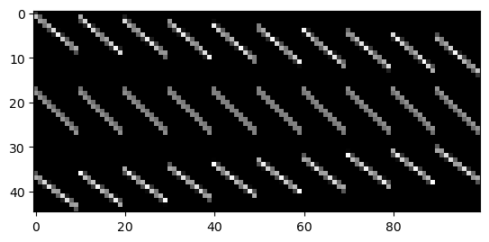

```python
# import the required packages and load the example data

import numpy as np
import matplotlib.pyplot as plt
from time import time
from scipy.sparse import coo_matrix

X_example= np.load("data/X_example.npy")


print(X_example.shape)
plt.imshow(X_example, cmap="gray")
plt.show()
```

The result of Construct_X is the same as what is wanted but some improvement could be done in code, in order to increase the speed of execution such as converting to radians with the usage of np.radians(alpha) as well as validating the calculated data such as possible outranged floored projected points which should be between 0 and Np-1

```python
# implement Construct_X, given M, the angles Alphas and Np
def construct_X(M, alphas, Np=None):

    # Set Np if required
    if Np==None:
        Np= np.ceil(np.sqrt(2)*M)
        if Np%2==0:
            Np+=1

    # print(Np)
    mid=Np//2 # define the middle of the pixel sensor
    # print(mid)

    # define the lenght of the flattended image and the height of the matrix
    D=int(M**2)
    N=int(Np*len(alphas))


    # start=time()

    #initialise C
    C= np.mgrid[0:M,0:M]
    C=C.reshape(2,M**2) - (M-1)/2
    C[[0,1]]=C[[1,0]] # swap the two rows

    # print(C)
    # stop=time()
    # print(f"Time for initialising C: {stop-start} s")


    # start=time()

    #lists to fill the data
    i_indices=[]
    j_indices=[]
    weights=[]

    for i,a in enumerate(alphas):
        a*= 2 * np.pi / 360     #adjust alpha to radian


        n= np.array([np.cos(a), -np.sin(a)])    # normal vector

        p= n.T @ C + mid    # calculate distances
        # print(p)

        # Calculate "bottom weights" aka. weights of the floor pixels and append weights
        weight_b=1-(p-np.floor(p))
        j_indices.append(range(D))
        i_indices.append(np.floor(p).astype(int) + int(i*Np))
        weights.append(weight_b)

        # calculate and append top weight
        weight_t=1-weight_b
        j_indices.append(range(D))
        i_indices.append(np.floor(p).astype(int)+1 + int(i*Np))
        weights.append(weight_t)

    # convert lists to arrays and flatten them
    i_indices=np.array(i_indices)
    i_indices=i_indices.flatten()
    j_indices=np.array(j_indices)
    j_indices=j_indices.flatten()
    weights=np.array(weights)
    weights=weights.flatten()

    # print(weights.shape)
    # print(i_indices.shape)
    # print(j_indices.shape)

    X = coo_matrix((weights, (i_indices, j_indices)), shape=(N, D), dtype = np.float32) # initialise the sparse matrix

    # stop=time()
    # print(f"Time for Calculating X: {stop-start} s")

    return X
```

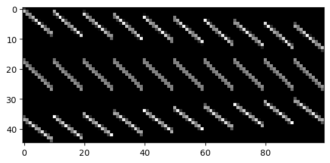

```
[]
```

```python
X=construct_X(10, [-33, 1, 42])


plt.imshow(X.A, cmap="gray")
plt.show()



print(X_example==X.A[False])
```

The implementation of part 2 is done correctly. The missing part of task is converting the Construct_X to sparse matrix with the help of .tocsc() which resulted the wrong calculation of sparsity of matrix. The nonezero elements are 1.85811663e9 for the large image, however, the sketch of the tomography image is clearly the same as it should be.

## Task 2

As we managed to implement Construct_X correctly, we move on to recover the image. First, we implement it by calculating the invariant matrix with the 77 pixel image. Secondly, we implement it by using the sparse matrix.

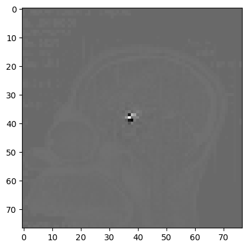

```python
a_77= np.load("hs_tomography/alphas_77.npy")
y_77= np.load("hs_tomography/y_77.npy")


X_77= construct_X(77, a_77, 109)
X_77= X_77.A
beta_77= np.linalg.inv(X_77.T @ X_77) @ X_77.T @y_77
beta_77=beta_77.reshape((77,77))
plt.imshow(beta_77, cmap="gray")
plt.show()
```

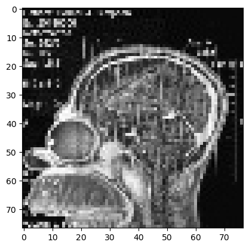

```python
from scipy.sparse.linalg import lsqr
from scipy import sparse

a_77= np.load("hs_tomography/alphas_77.npy")
y_77= np.load("hs_tomography/y_77.npy")


X_77= construct_X(77, a_77, 109)

beta_77= lsqr(X_77, y_77)[0]
beta_77=beta_77.reshape((77,77))
plt.imshow(beta_77, cmap="gray")
plt.show()
```

Let's move on the the 195 pixel image using the sparse matrix.

[figure not shown]

```
X has exactly 13535953 nonzero elements
There are 179 angles
```

```python
a_195= np.load("hs_tomography/alphas_195.npy")
y_195= np.load("hs_tomography/y_195.npy")


X_195= construct_X(195, a_195, 275)


# start=time()

beta_195= lsqr(X_195, y_195, atol=1e-05, btol=1e-05)[0]
beta_195=beta_195.reshape((195,195))
plt.imshow(beta_195, cmap="gray")
plt.show()

_, _, nonzeroElements = sparse.find(X_195)
print("X has exactly " + str(nonzeroElements.size) + " nonzero elements")
print(f"There are {a_195.size} angles")




# stop=time()
# print(f"Time for calculating beta: {stop-start}s")
```

We find that our patient H.S. has a pen stuck in his head. It is clearly visible in the left center of his head. Probably, the comic artist forgot it in his head when he drew Mr. Simpson. We would propose that next time Philipp Aretz could sketch Homer as he is very talented in drawing him!

We see that there are 13,535,953 non-zero elements. As there are 179 angles measured, each image has 195^2 pixel and each pixel influences 2 detector pixel, at maximum $179*2*195^2=13,612,950$. This tells us, that not in every measurement, each pixel hits two detector pixel.

```python
179*2*195**2
```

```
13612950
```

The same problem here as it is in Task 2, which caused the late discovery of the correct number of proper angles to show the cause of headache. The recontsruction of alpha and y isn't correctly implemented, which is a naive way of thinking to divide the angles in to 10 equell size. As a result the estimated number of reduced angles are far away from what it should be, 139 compared to the 32. The implementation of this part should be replaced completely by the worked example. Lastly they did great job and the overal result is satisfactory,

## Task 3

Now, we want to reduce the number of measured angles to reduce the radiation dose. In theory, as only positive values are measured, there have to be $195^2 = 38025$ non-zero entries in the measured vector y_195 to solve the linear equation system correctly.

```python
print(195**2)
print(y_195.size)
print(np.count_nonzero(y_195))

print(np.count_nonzero(y_195[:41800]))
print(np.count_nonzero(y_195[:41800])/275)

print(a_195)
```

```
38025
49225
44613
38200
138.9090909090909
[-90 -89 -88 -87 -86 -85 -84 -83 -82 -81 -80 -79 -78 -77 -76 -75 -74 -73
 -72 -71 -70 -69 -68 -67 -66 -65 -64 -63 -62 -61 -60 -59 -58 -57 -56 -55
 -54 -53 -52 -51 -50 -49 -48 -47 -46 -45 -44 -43 -42 -41 -40 -39 -38 -37
 -36 -35 -34 -33 -32 -31 -30 -29 -28 -27 -26 -25 -24 -23 -22 -21 -20 -19
 -18 -17 -16 -15 -14 -13 -12 -11 -10  -9  -8  -7  -6  -5  -4  -3  -2  -1
   0   1   2   3   4   5   6   7   8   9  10  11  12  13  14  15  16  17
  18  19  20  21  22  23  24  25  26  27  28  29  30  31  32  33  34  35
  36  37  38  39  40  41  42  43  44  45  46  47  48  49  50  51  52  53
  54  55  56  57  58  59  60  61  62  63  64  65  66  67  68  69  70  71
  72  73  74  75  76  77  78  79  80  81  82  83  84  85  86  87  88]
```

Lets try different numbers of angles and see if we can reconstruct the image well enough to give a diagnose.

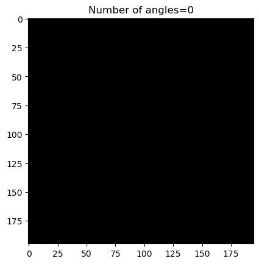

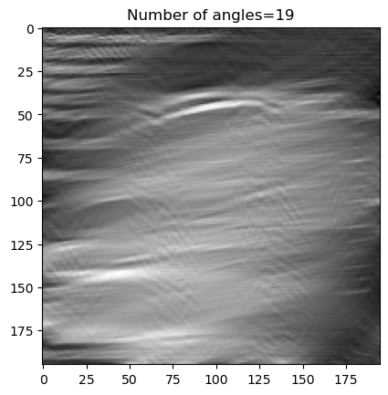

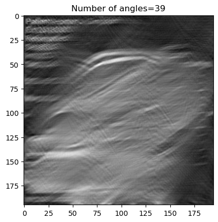

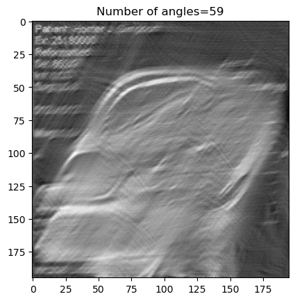

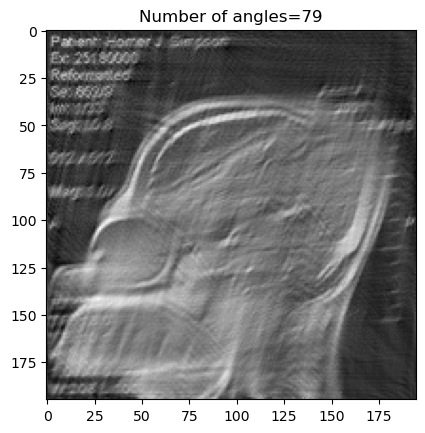

[figure not shown]

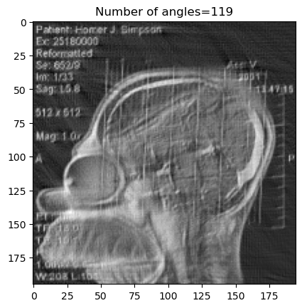

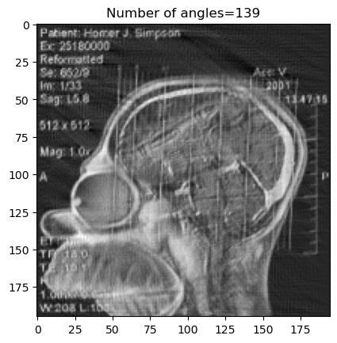

[figure not shown]

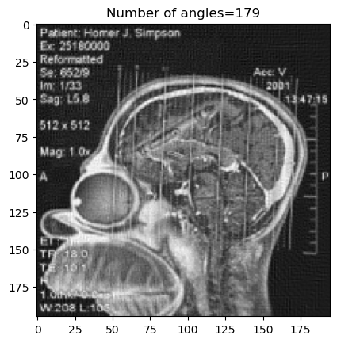

```python
n_values= np.linspace(0,a_195.size, 10).astype(int)

for n in n_values:

    X_195= construct_X(195, a_195[:int(n)], 275)
    beta_195= lsqr(X_195, y_195[:int(n*275)], atol=1e-5, btol=1e-5)[0]
    beta_195=beta_195.reshape((195,195))
    plt.imshow(beta_195, cmap="gray")
    plt.title(f"Number of angles={n}")
    plt.show()
```

Against our expectations we are already able to see a decent image with only 119 measured angles. In this image we can clearly recognize the pen. With less angles, we can see the shape. If we had not know what we were looking for, it would have been hard to identify the object as a pen.

Nevertheless, our reconstructions show that the principly "The more the merrier" holds. Maybe, if we picked the angles randomly, we would have obtained a better image as we simply cancled out a region of angles. So, there's still room for improvements.